# AI-CA4

## Ali Edalat

### import

```python
import matplotlib.pyplot as plt
import pandas as pd
import numpy as np
from sklearn.neighbors import KNeighborsClassifier
from sklearn.tree import DecisionTreeClassifier
import graphviz
from sklearn import tree
from sklearn.ensemble import RandomForestClassifier
from sklearn.linear_model import LogisticRegression
from sklearn.cluster import KMeans
```

### 0)

```
The below Image should be a  [7]
```

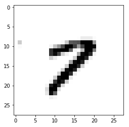

```python
train_imgs=pd.read_csv('MNIST/train_data.csv',  header=None)
train_labels=pd.read_csv('MNIST/train_label.csv',  header=None)
test_imgs=pd.read_csv('MNIST/test_data.csv',  header=None)
test_labels=pd.read_csv('MNIST/test_label.csv',  header=None)
img = train_imgs.iloc[1401, :].values.reshape(28, 28)
plt.imshow(img, cmap="Greys")
print("The below Image should be a ", train_labels.iloc[:, 0:1].values[1401])
plt.show()
```

### 1)

#### یک الگوریتم یادگیری ماشین است که برای مشخص کردن کلاس یک نمونه جدید از چند نزدیک ترین نمونه به نمونه تست استفاده می کند. برای مثال در این تمرین تابع تعیین فاصله را می توان فاصله روشنایی پیکسل های یک تصویر به صورت مجموع مربعات اختلاف روشنایی پیکسل های دو تصویر در نظر گرفت. در این الگوریتم فاصله تمام نمونه های تمرین تا نمونه تست تعیین می شود و نمونه های تمرین با توجه به این فاصله مرتب می شوند و فرد نمونه از نزدیک ترین نمونه های تمرین انتخاب می شود و لیبلی که در میان آن ها بیشتر دیده می شود به عنوان لیبل نمونه تست در نظر گرفته می شود. و به همین دلیل یک روش یادگیری بر پایه نمونه ها تمرین در حافظه است.

### 2)

```python
trainData = []
testData = []
testLabels = test_labels.iloc[:, 0].values
trainLabels = train_labels.iloc[:, 0].values
for x in range(len(train_imgs.index)):
	trainData.append(train_imgs.iloc[x, :].values)
for x in range(len(test_imgs.index)):
	testData.append(test_imgs.iloc[x, :].values)

neigh = KNeighborsClassifier(n_neighbors=9)
neigh.fit(trainData, trainLabels)
score = neigh.score(trainData, trainLabels)
print("train k=%d, accuracy=%.2f%%" % (9, score * 100))
score = neigh.score(testData, testLabels)
print("test k=%d, accuracy=%.2f%%" % (9, score * 100))
```

```
train k=9, accuracy=92.10%
test k=9, accuracy=90.00%
```

### 3)

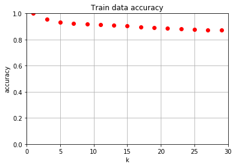

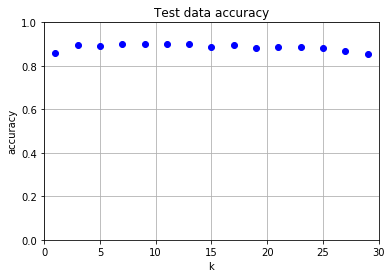

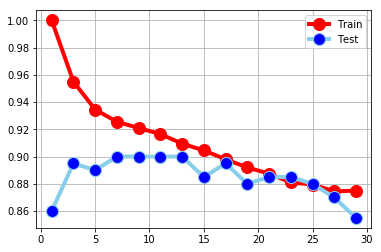

```python
scoreTrain = []
scoreTest = []
for x in range(1,30,2):
	neigh = KNeighborsClassifier(n_neighbors=x)
	neigh.fit(trainData, trainLabels)
	scoreTrain.append(neigh.score(trainData, trainLabels))
	scoreTest.append(neigh.score(testData, testLabels))

plt.plot([x for x in range(1,30,2)], scoreTrain, 'ro')
plt.axis([0, 30, 0, 1])
plt.xlabel('k')
plt.ylabel('accuracy')
plt.title('Train data accuracy')
plt.grid()
plt.show()
plt.plot([x for x in range(1,30,2)], scoreTest, 'bo')
plt.axis([0, 30, 0, 1])
plt.xlabel('k')
plt.ylabel('accuracy')
plt.title('Test data accuracy')
plt.grid()
plt.show()
df=pd.DataFrame({'x': range(1,30,2), 'Train': scoreTrain, 'Test': scoreTest})
plt.plot( 'x', 'Train', data=df, marker='o', markerfacecolor='red', markersize=12, color='red', linewidth=4)
plt.plot( 'x', 'Test', data=df, marker='o', markerfacecolor='blue', markersize=12, color='skyblue', linewidth=4)
plt.grid()
plt.legend()
```

### 4)

#### افزایش می یابد. دلیل این موضوع این است که داده ها با فاصله کم از نمونه تست وجود دارند که لیبل اشتباه و دور از نمونه دارند که با افزایش تعداد نمونه ها برای تصمیم گیری این داده های نزدیک و گمراه کننده در نمونه های رای دهنده بیشتر می شوند و باعث خطا بیشتر می شوند.

### 5)

```
neighbor  1 The below Image should be a  7
```

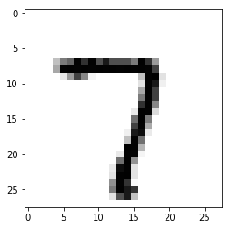

```
neighbor  2 The below Image should be a  7
```

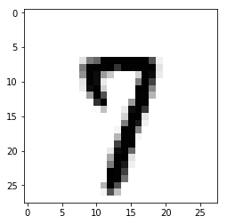

```
neighbor  3 The below Image should be a  7
```

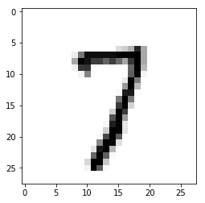

```
neighbor  4 The below Image should be a  7
```

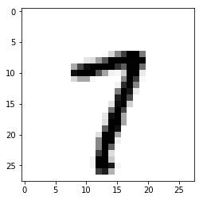

```python
neigh = KNeighborsClassifier(n_neighbors=4)
neigh.fit(trainData, trainLabels)
neighbors = neigh.kneighbors([test_imgs.iloc[1, :].values], return_distance=False)
c = 0
for x in neighbors[0]:
	img = train_imgs.iloc[x, :].values.reshape(28, 28)
	plt.imshow(img, cmap="Greys")
	print("neighbor ", c+1,"The below Image should be a ", test_labels.iloc[:, 0].values[1])
	c += 1
	plt.show()
```

### 6)

#### یکی از مشکلات اصلی این الگوریتم این است که برای بدست آوردن لیبل هر نمونه تست باید فاصله تمام نمونه های تمرین از داده تست بدست بیاید و داده های تمرین بر این اساس مرتب شوند و رای گیری صورت گیرد که برای داده با سایز زیاد هزینه زمانی بسیار بالایی دارد. مشکل اصلی این است که در این الگوریتم از داده های تمرین یادگیری صورت نمی گیرد و فقط از این داده ها برای کلاس بندی استفاده می شود که به همین دلیل به داده های تمرین بسیار وابسته است و باعث می شود نسبت به داده های نویزی مقاوم نباشد.

### 7)

#### در این روش یادگیری از یک درخت تصمیم برای تعیین کلاس نمونه استفاده می شود تا با توجه به مشاهدات از یک نمونه به استنتاج در باره لیبل نمونه برسیم. در این درخت در گره های میانی پرسش هایی در باره ویژگی های نمونه وجود دارد که با توجه به نمونه یکی از شاخه های خارج شده از آن انتخاب می شود و این شاخه ها ما را به لیبل نمونه تست می رسانند. در این روش درخت با توجه به داده های تمرین ساخته می شود که در صورت ایجاد تغییر در داده های تمرین درخت تصمیم دچار تغییرات زیادی می شود

### 8)

```python
clf = DecisionTreeClassifier(random_state=0)
clf.fit(trainData, trainLabels)
score = clf.score(trainData, trainLabels)
print("train dp=none, accuracy=%.2f%%" % (score * 100))
score = clf.score(testData, testLabels)
print("test dp=none, accuracy=%.2f%%" % (score * 100))
```

```
train dp=none, accuracy=100.00%
test dp=none, accuracy=72.50%
```

### 9)

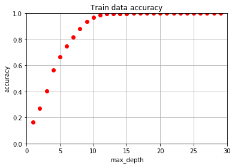

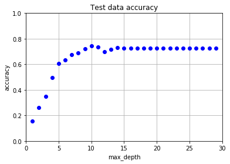

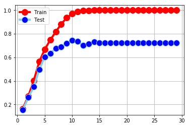

```python
scoreTrain = []
scoreTest = []
for x in range(1,30):
	clf = DecisionTreeClassifier(max_depth=x,random_state=0)
	clf.fit(trainData, trainLabels)
	scoreTrain.append(clf.score(trainData, trainLabels))
	scoreTest.append(clf.score(testData, testLabels))

plt.plot([x for x in range(1,30)], scoreTrain, 'ro')
plt.axis([0, 30, 0, 1])
plt.xlabel('max_depth')
plt.ylabel('accuracy')
plt.title('Train data accuracy')
plt.grid()
plt.show()
plt.plot([x for x in range(1,30)], scoreTest, 'bo')
plt.axis([0, 30, 0, 1])
plt.xlabel('max_depth')
plt.ylabel('accuracy')
plt.title('Test data accuracy')
plt.grid()
plt.show()
df=pd.DataFrame({'x': range(1,30), 'Train': scoreTrain, 'Test': scoreTest})
plt.plot( 'x', 'Train', data=df, marker='o', markerfacecolor='red', markersize=12, color='red', linewidth=4)
plt.plot( 'x', 'Test', data=df, marker='o', markerfacecolor='blue', markersize=12, color='skyblue', linewidth=4)
plt.grid()
plt.legend()
```

### 10)

```python
clf = DecisionTreeClassifier(max_depth=7,random_state=0)
clf.fit(trainData, trainLabels)
dot_data = tree.export_graphviz(clf, out_file=None,filled=True, rounded=True,special_characters=True)
graph = graphviz.Source(dot_data)
graph
```

[figure not shown]

### 11)

#### زمانی که ارتفاع درخت بیشتر از حد لازم برای تشخیص لیبل یک نمونه باشد اورفیت رخ می دهد. دلیل این موضوع ریز شدن تصمیمات درخت با توجه به داده های تمرین است که باعث می شود مدل حاصل کلی نباشد. برای اثبات این موضوع ابتدا عمق درخت را ۷ قرار می دهیم و دقت بر روی داده های تست و تمرین را بدست می آوریم و همین کار را برای عمق ۱۵ انجام می دهیم. اختلاف زیاد در دقت داده های تست و تمرین در یک عمق نشان دهنده رخ دادن اورفیت است که در عمق ۱۵ رخ می دهد.

```python
clf = DecisionTreeClassifier(max_depth=7,random_state=0)
clf.fit(trainData, trainLabels)
score3 = clf.score(trainData, trainLabels)
print("train dp=7, accuracy=%.2f%%" % (score3 * 100))
score4 = clf.score(testData, testLabels)
print("test dp=7, accuracy=%.2f%%" % (score4 * 100))
clf2 = DecisionTreeClassifier(max_depth=15,random_state=0)
clf2.fit(trainData, trainLabels)
score1 = clf2.score(trainData, trainLabels)
print("train dp=15, accuracy=%.2f%%" % (score1 * 100))
score2 = clf2.score(testData, testLabels)
print("test dp=15, accuracy=%.2f%%" % (score2 * 100))
```

```
train dp=7, accuracy=81.60%
test dp=7, accuracy=67.50%
train dp=15, accuracy=99.95%
test dp=15, accuracy=72.50%
```

### 12)

#### جنگل تصادفی یک الگوریتم یادگیری ماشین است که در این الگوریتم داده تمرین به بخش هایی تقسیم می شود که از هم مجزا هستند و هر بخش توسط یک درخت تصمیم عمیق یادگرفته می شود و نتایج این درخت ها میانگین یا مد گرفته می شود. در کلاس بندی از چون با یک سری لیبل غیر عددی مواجه هستیم از مد گیری می توان استفاده کرد. این الگوریتم یک روش برای حل مشکل یادگیری بیش از حد درخت های عمیق است که با شکستن داده و رای گیری میان چند مدل بر روی داده تمرین سعی در حل این مشکل دارد

### 13)

```python
clf = RandomForestClassifier(n_estimators=12, max_depth=12,random_state=0)
clf.fit(trainData, trainLabels)
score3 = clf.score(trainData, trainLabels)
print("train n_estimators=12, max_depth=7, accuracy=%.2f%%" % (score3 * 100))
score4 = clf.score(testData, testLabels)
print("test n_estimators=12, max_depth=7, accuracy=%.2f%%" % (score4 * 100))
```

[output not shown]

### 14)

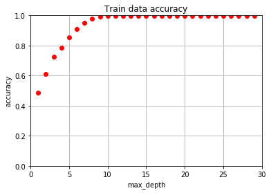

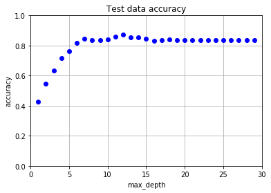

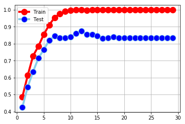

```python
scoreTrain = []
scoreTest = []
for x in range(1,30):
	clf = RandomForestClassifier(n_estimators=12, max_depth=x,random_state=0)
	clf.fit(trainData, trainLabels)
	scoreTrain.append(clf.score(trainData, trainLabels))
	scoreTest.append(clf.score(testData, testLabels))

plt.plot([x for x in range(1,30)], scoreTrain, 'ro')
plt.axis([0, 30, 0, 1])
plt.xlabel('max_depth')
plt.ylabel('accuracy')
plt.title('Train data accuracy')
plt.grid()
plt.show()
plt.plot([x for x in range(1,30)], scoreTest, 'bo')
plt.axis([0, 30, 0, 1])
plt.xlabel('max_depth')
plt.ylabel('accuracy')
plt.title('Test data accuracy')
plt.grid()
plt.show()
df=pd.DataFrame({'x': range(1,30), 'Train': scoreTrain, 'Test': scoreTest})
plt.plot( 'x', 'Train', data=df, marker='o', markerfacecolor='red', markersize=12, color='red', linewidth=4)
plt.plot( 'x', 'Test', data=df, marker='o', markerfacecolor='blue', markersize=12, color='skyblue', linewidth=4)
plt.grid()
plt.legend()
```

#### عمق ۱۲ در صورتی که تعداد درخت ها ۱۲ باشد و بقیه هایپر پارامتر ها مقدار ابتدایی خود را داشته باشند بهترین دقت را دارد.

### 15)

#### تعداد درخت ها مشخص کننده تعداد درخت های تصمیمی است که بر روی قسمت های مختلف و مجزای دیتای تمرین، تمرین داده می شوند تا میان خروجی های این درخت ها برای یک نمونه جدید میانگین گرفته شود

#### حداقل تعداد نمونه های مورد نیاز برای منشعب کردن یک گره درونی می باشد min_samples_split

#### تعداد ماکسیمم ویژگی ها وقتی به دنبال بهترین انشعاب هستیم را مشخص می کند max_features

```
max_depth=12,random_state=0
```

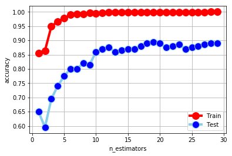

```
n_estimators=19, max_depth=12, random_state=0
```

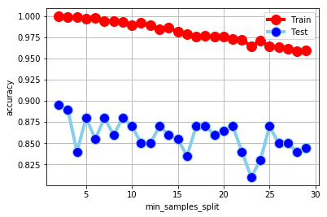

[output not shown]

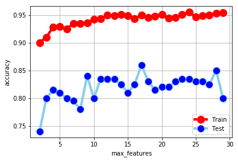

```python
scoreTrain = []
scoreTest = []
for x in range(1,30):
	clf = RandomForestClassifier(n_estimators=x, max_depth=12,random_state=0)
	clf.fit(trainData, trainLabels)
	scoreTrain.append(clf.score(trainData, trainLabels))
	scoreTest.append(clf.score(testData, testLabels))

df=pd.DataFrame({'x': range(1,30), 'Train': scoreTrain, 'Test': scoreTest})
plt.plot( 'x', 'Train', data=df, marker='o', markerfacecolor='red', markersize=12, color='red', linewidth=4)
plt.plot( 'x', 'Test', data=df, marker='o', markerfacecolor='blue', markersize=12, color='skyblue', linewidth=4)
plt.grid()
plt.xlabel('n_estimators')
plt.ylabel('accuracy')
print("max_depth=12,random_state=0")
plt.legend()
plt.show()

scoreTrain = []
scoreTest = []
for x in range(2,30):
	clf = RandomForestClassifier(n_estimators=19, max_depth=12, min_samples_split=x,random_state=0)
	clf.fit(trainData, trainLabels)
	scoreTrain.append(clf.score(trainData, trainLabels))
	scoreTest.append(clf.score(testData, testLabels))

df=pd.DataFrame({'x': range(2,30), 'Train': scoreTrain, 'Test': scoreTest})
plt.plot( 'x', 'Train', data=df, marker='o', markerfacecolor='red', markersize=12, color='red', linewidth=4)
plt.plot( 'x', 'Test', data=df, marker='o', markerfacecolor='blue', markersize=12, color='skyblue', linewidth=4)
plt.grid()
plt.xlabel('min_samples_split')
plt.ylabel('accuracy')
print("n_estimators=19, max_depth=12, random_state=0")
plt.legend()
plt.show()

scoreTrain = []
scoreTest = []
for x in range(2,30):
	clf = RandomForestClassifier(n_estimators=12, max_depth=12, min_samples_split=25, max_features=x, random_state=0)
	clf.fit(trainData, trainLabels)
	scoreTrain.append(clf.score(trainData, trainLabels))
	scoreTest.append(clf.score(testData, testLabels))

df=pd.DataFrame({'x': range(2,30), 'Train': scoreTrain, 'Test': scoreTest})
plt.plot( 'x', 'Train', data=df, marker='o', markerfacecolor='red', markersize=12, color='red', linewidth=4)
plt.plot( 'x', 'Test', data=df, marker='o', markerfacecolor='blue', markersize=12, color='skyblue', linewidth=4)
plt.grid()
plt.xlabel('max_features')
plt.ylabel('accuracy')
print("n_estimators=12, max_depth=12, min_samples_split=2, random_state=0")
plt.legend()
plt.show()
```

### 16)

```python
clf = RandomForestClassifier(n_estimators=1, max_depth=7, random_state=0)
clf.fit(trainData, trainLabels)
score3 = clf.score(trainData, trainLabels)
print("RF train n_estimators=1, dp=7, accuracy=%.2f%%" % (score3 * 100))
score4 = clf.score(testData, testLabels)
print("RF test n_estimators=1, dp=7, accuracy=%.2f%%" % (score4 * 100))
clf = DecisionTreeClassifier(max_depth=7,random_state=0)
clf.fit(trainData, trainLabels)
score3 = clf.score(trainData, trainLabels)
print("DT train dp=7, accuracy=%.2f%%" % (score3 * 100))
score4 = clf.score(testData, testLabels)
print("DT test dp=7, accuracy=%.2f%%" % (score4 * 100))
```

```
RF train n_estimators=1, dp=7, accuracy=69.55%
RF test n_estimators=1, dp=7, accuracy=53.00%
DT train dp=7, accuracy=81.60%
DT test dp=7, accuracy=67.50%
```

#### خیر.در جنگل اززیر مجموعه ای رندوم از ویژگی های دیتا برای درست کردن درخت استفاده می شود که این موضوع با پارامتر ماکسیمم ویژگی تعیین می شود.در درخت تصمیم تمام داده تمرین در نظر گرفته می شود ولی در جنگل زیر نمونه ی از داده تمرین استفاده می شود

#### برای ساخت درخت در جنگل استفاده می شود bootstrap زیرنمونه

### 17)

#### رگرسیون لجستیک بر خلاف نامش یک مدل خطی برای کلاس بندی داده ها می باشد.که به آن کلاسگر بر اساس بیشینه اینتروپی نیز می گویند. در این الگوریتم به دنبال ماتریس ضرایب داده ها هستیم تا حاصل ضرب داده ها در ضرایب برابر تابعی از احتمال رخداد یک خروجی ممکن از یک آزمایش شود

### 18)

```python
clf = LogisticRegression(random_state=0, solver='lbfgs', max_iter=100, multi_class='multinomial').fit(trainData, trainLabels)
score3 = clf.score(trainData, trainLabels)
print("train accuracy=%.2f%%" % (score3 * 100))
score4 = clf.score(testData, testLabels)
print("test accuracy=%.2f%%" % (score4 * 100))
```

```
train accuracy=100.00%
test accuracy=86.00%
```

### 19)

#### کلاستر تشکیل می شود که در ابتدا به صورت رندوم از دیتای ورودی بین این کلاستر ها داده توزیع می شود. سپس داده در k در این الگوریتم به تعداد

#### کلاستری قرار می گیرد که مربع فاصله آن از میانگین کلاستر کمینه باشد. برای کلاس بندی داده های تست نیز از فاصله از میانگین کلاستر استفاده می شود.

### 20)

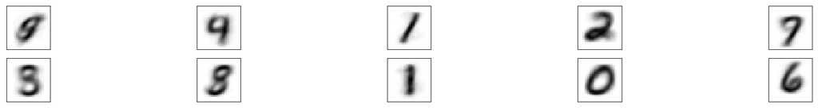

```python
kmeans = KMeans(n_clusters=10, random_state=0).fit(trainData)
centers = kmeans.cluster_centers_.reshape(10, 28, 28)
fig, ax = plt.subplots(2, 5, figsize=(28, 3))
for axi, center in zip(ax.flat, centers):
    axi.set(xticks=[], yticks=[])
    axi.imshow(center, interpolation='nearest', cmap=plt.cm.binary)
```

### 21)

```python
kmeans = KMeans(n_clusters=10, random_state=0).fit(trainData)
predict = kmeans.predict(testData)
labels = kmeans.labels_
classes = [[] for x in range(0,10)]
for i in range(0, len(trainData)):
    classes[labels[i]-1].append(trainLabels[i])
# print(classes)
pred = [max(set(classes[i]), key=classes[i].count) for i in range(0,10)]
# print(pred)
c = 0
i = 0
for x in predict:
    if pred[x-1] == testLabels[i]:
        c += 1
    i += 1
print('accuracy: %', (float(c)*100)/i)
```

```
accuracy: % 55.5
```

### 22)

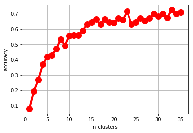

```python
accs = []
for k in range(1,36):
	kmeans = KMeans(n_clusters=k, random_state=0).fit(trainData)
	predict = kmeans.predict(testData)
	labels = kmeans.labels_
	classes = [[] for x in range(0,k)]
	for i in range(0, len(trainData)):
		classes[labels[i]-1].append(trainLabels[i])
	pred = [max(set(classes[i]), key=classes[i].count) for i in range(0,k)]
	c = 0
	i = 0
	for x in predict:
		if pred[x-1] == testLabels[i]:
			c += 1
		i += 1
	accs.append(float(c)/i)
df=pd.DataFrame({'n': range(1,36), 'accuracy': accs})
plt.plot( 'n', 'accuracy', data=df, marker='o', markerfacecolor='red', markersize=12, color='red', linewidth=4)
plt.grid()
plt.xlabel('n_clusters')
plt.ylabel('accuracy')
plt.show()
```

#### با توجه به نمودار بالا دیده می شود افزایش تعداد دسته ها همیشه باعث افزایش دقت نمی شود. در این سوال ما با ۱۰ دسته مواجه هستیم. در این الگوریتم تعیین دسته نمونه با توجه به مرکز دسته است. در این جا اگر داده های بسیار زیاد و نزدیک به هر عدد را تمرین کنیم پس می توان ۱۰ دسته داشت که هر یک نماد یک عدد است. در این جا با افزایش تا جایی می توان بعضی داده های پرت را در چند دسته غیر اصلی گیر انداخت تا داده ها بهتر دسته بندی شوند.

```
n_clusters= 33  accuracy: % 72.5
```

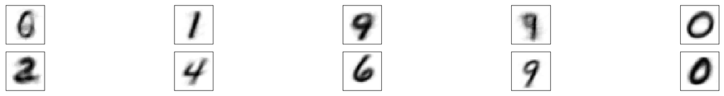

```python
kmeans = KMeans(n_clusters=33, random_state=0).fit(trainData)
centers = kmeans.cluster_centers_.reshape(33, 28, 28)
fig, ax = plt.subplots(2, 5, figsize=(28, 3))
for axi, center in zip(ax.flat, centers):
	axi.set(xticks=[], yticks=[])
	axi.imshow(center, interpolation='nearest', cmap=plt.cm.binary)
predict = kmeans.predict(testData)
labels = kmeans.labels_
classes = [[] for x in range(0,33)]
for i in range(0, len(trainData)):
	classes[labels[i]-1].append(trainLabels[i])
pred = [max(set(classes[i]), key=classes[i].count) for i in range(0,33)]
c = 0
i = 0
for x in predict:
	if pred[x-1] == testLabels[i]:
		c += 1
	i += 1
print('n_clusters=',33,' accuracy: %', (float(c)*100)/i)
```

### 23)

#### برای پاسخ گویی به کویری جدید باید فاصله تمام نمونه های تمرین از نمونه جدید باید محاسبه شود و این فاصله ها باید سورت شود KNN چون در

#### فقط فاصله از مراکز کلاسترها بایدمحاسبه شود و مراکز به روز شود k-means در حالی که در

### 24)

#### این الگوریتم به ازای هایپر پارامتر تعداد افراد شرکت کننده در رای گیری ۹ دقت ۹۰ درصد بر روی داده های تست را داشت.

### 25)

```
Confusion matrix, without normalization
[[15  0  0  0  0  0  1  0  0  0]
 [ 0 25  0  0  0  0  0  0  0  0]
 [ 0  2 24  0  0  0  0  1  0  0]
 [ 0  0  1 15  0  0  0  0  0  0]
 [ 0  0  0  0 16  0  0  1  0  2]
 [ 0  0  0  0  0 11  0  0  0  1]
 [ 0  2  0  0  2  0 24  0  0  0]
 [ 0  2  0  0  0  0  0 18  0  1]
 [ 1  0  0  0  0  0  0  1 17  0]
 [ 0  0  0  0  0  0  1  0  1 15]]
Normalized confusion matrix
[[0.94 0.   0.   0.   0.   0.   0.06 0.   0.   0.  ]
 [0.   1.   0.   0.   0.   0.   0.   0.   0.   0.  ]
 [0.   0.07 0.89 0.   0.   0.   0.   0.04 0.   0.  ]
 [0.   0.   0.06 0.94 0.   0.   0.   0.   0.   0.  ]
 [0.   0.   0.   0.   0.84 0.   0.   0.05 0.   0.11]
 [0.   0.   0.   0.   0.   0.92 0.   0.   0.   0.08]
 [0.   0.07 0.   0.   0.07 0.   0.86 0.   0.   0.  ]
 [0.   0.1  0.   0.   0.   0.   0.   0.86 0.   0.05]
 [0.05 0.   0.   0.   0.   0.   0.   0.05 0.89 0.  ]
 [0.   0.   0.   0.   0.   0.   0.06 0.   0.06 0.88]]
```

[figure not shown]

[figure not shown]

```python
from sklearn.metrics import confusion_matrix
from sklearn.utils.multiclass import unique_labels

neigh = KNeighborsClassifier(n_neighbors=9)
neigh.fit(trainData, trainLabels)
pred = neigh.predict(testData)

def plot_confusion_matrix(y_true, y_pred, classes,
                          normalize=False,
                          title=None,
                          cmap=plt.cm.Blues):
    """
    This function prints and plots the confusion matrix.
    Normalization can be applied by setting `normalize=True`.
    """
    if not title:
        if normalize:
            title = 'Normalized confusion matrix'
        else:
            title = 'Confusion matrix, without normalization'

    # Compute confusion matrix
    cm = confusion_matrix(y_true, y_pred)
    # Only use the labels that appear in the data
    classes = classes[unique_labels(y_true, y_pred)]
    if normalize:
        cm = cm.astype('float') / cm.sum(axis=1)[:, np.newaxis]
        print("Normalized confusion matrix")
    else:
        print('Confusion matrix, without normalization')

    print(cm)

    fig, ax = plt.subplots()
    im = ax.imshow(cm, interpolation='nearest', cmap=cmap)
    ax.figure.colorbar(im, ax=ax)
    # We want to show all ticks...
    ax.set(xticks=np.arange(cm.shape[1]),
           yticks=np.arange(cm.shape[0]),
           # ... and label them with the respective list entries
           xticklabels=classes, yticklabels=classes,
           title=title,
           ylabel='True label',
           xlabel='Predicted label')

    # Rotate the tick labels and set their alignment.
    plt.setp(ax.get_xticklabels(), rotation=45, ha="right",
             rotation_mode="anchor")

    # Loop over data dimensions and create text annotations.
    fmt = '.2f' if normalize else 'd'
    thresh = cm.max() / 2.
    for i in range(cm.shape[0]):
        for j in range(cm.shape[1]):
            ax.text(j, i, format(cm[i, j], fmt),
                    ha="center", va="center",
                    color="white" if cm[i, j] > thresh else "black")
    fig.tight_layout()
    return ax


np.set_printoptions(precision=2)
# Plot non-normalized confusion matrix
plot_confusion_matrix(testLabels, pred, classes=testLabels,
                      title='Confusion matrix, without normalization')

# Plot normalized confusion matrix
plot_confusion_matrix(testLabels, pred, classes=testLabels, normalize=True,
                      title='Normalized confusion matrix')

plt.show()
```

### 26)

```
The below Image should be a  3
```

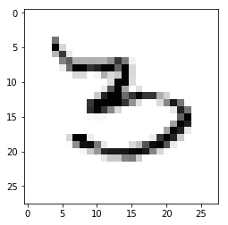

```
KNN predict:  2 this prediction is  not correct.
DT predict:  3 this prediction is   correct.
RF predict:  5 this prediction is  not correct.
LR predict:  5 this prediction is  not correct.
K-means predict:  4 this prediction is  not correct.
```

```python
neigh = KNeighborsClassifier(n_neighbors=9)
neigh.fit(trainData, trainLabels)
KNNpred = neigh.predict(testData)
clf = DecisionTreeClassifier(random_state=0)
clf.fit(trainData, trainLabels)
DTpred = clf.predict(testData)
clfr = RandomForestClassifier(n_estimators=12, max_depth=12,random_state=0)
clfr.fit(trainData, trainLabels)
RFpred = clfr.predict(testData)
clfl = LogisticRegression(random_state=0, solver='lbfgs', max_iter=100, multi_class='multinomial').fit(trainData, trainLabels)
LRpred = clfl.predict(testData)
kmeans = KMeans(n_clusters=33, random_state=0).fit(trainData)
predict = kmeans.predict(testData)
labels = kmeans.labels_
classes = [[] for x in range(0,33)]
for i in range(0, len(trainData)):
	classes[labels[i]-1].append(trainLabels[i])
pred = [max(set(classes[i]), key=classes[i].count) for i in range(0,33)]
img = testData[0].reshape(28, 28)
plt.imshow(img, cmap="Greys")
print("The below Image should be a ", testLabels[0])
plt.show()
print("KNN predict: ", KNNpred[0] , "this prediction is ","" if KNNpred[0] == testLabels[0] else "not","correct.")
print("DT predict: ", DTpred[0] , "this prediction is ","" if DTpred[0] == testLabels[0] else "not","correct.")
print("RF predict: ", RFpred[0] , "this prediction is ","" if RFpred[0] == testLabels[0] else "not","correct.")
print("LR predict: ", LRpred[0] , "this prediction is ","" if LRpred[0] == testLabels[0] else "not","correct.")
print("K-means predict: ", pred[predict[0]-1] , "this prediction is ","" if pred[predict[0]-1] == testLabels[0] else "not","correct.")
```

### 27)

#### یک تکنیک برای بازنویسی و تبدیل یک داده چند بعدی به بعد های کمتر است به طوری که داده حاصل بیشترین فرق داده اولیه را نسبت به بقیه بتواند بیان کند. دلیل استفاده از آن کاهش حجم داده تمرین و افزایش سرعت است به طوری که دقت نهایی تغییر زیادی نکند ولی چون داده های متمایز کننده را فقط در نظر می گیریم در الگوریتم های وابسته به تمایز داده نتایج می تواند کمی فرق کند.

### 28)

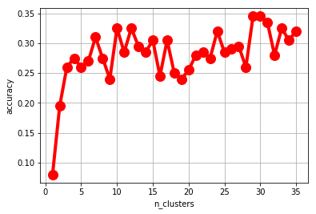

```python
import numpy as np
from sklearn.decomposition import PCA
np.random.seed(42)

accs = []
PCAtrain = PCA(n_components=2).fit_transform(trainData)
PCAtest = PCA(n_components=2).fit_transform(testData)
for k in range(1,36):
	kmeans = KMeans(init='k-means++', n_clusters=k, n_init=10).fit(PCAtrain)
	predict = kmeans.predict(PCAtest)
	labels = kmeans.labels_
	classes = [[] for x in range(0,k)]
	for i in range(0, len(trainData)):
		classes[labels[i]-1].append(trainLabels[i])
	pred = [max(set(classes[i]), key=classes[i].count) for i in range(0,k)]
# 	print(pred)
# 	print(classes)
# 	print(labels)
	c = 0
	i = 0
	for x in predict:
		if pred[x-1] == testLabels[i]:
			c += 1
		i += 1
	accs.append(float(c)/i)
df=pd.DataFrame({'n': range(1,36), 'accuracy': accs})
plt.plot( 'n', 'accuracy', data=df, marker='o', markerfacecolor='red', markersize=12, color='red', linewidth=4)
plt.grid()
plt.xlabel('n_clusters')
plt.ylabel('accuracy')
plt.show()
```

#### سرعت محاسبه افزایش می یابد ولی برای کاهش حجم دیتا از دقت کاسته می شود.